# Goodreads Reviews Analysis

David Nicolay 26296918, Kellen Mossner 26024284, Matthew Holm 26067404

2024-10-01

## Load Libraries and Custom Theme

Setting up custom themes

```r
darjeeling1 <- c("#B22222", "#00A08A", "#F2AD00", "#F98400", "#5BBCD6")
axis_color <- "#2D2D2D"

# Set the font for plots
font_add_google("Montserrat") # Formal font
showtext_auto()

my_custom_theme <- theme_minimal() +
  theme(
    plot.background = element_rect(fill = "#F3F1DE", color = NA),
    panel.background = element_rect(fill = "#F3F1DE", color = NA),
    title = element_text(color = "#2D2D2D", size = 20, family = "Montserrat"),
    axis.text = element_text(color = "#2D2D2D", size = 12, family = "Montserrat"),
    axis.title = element_text(face = "bold", color = "#FF8500", size = 14, family = "Montserrat"),
    legend.background = element_rect(fill = "#F3F1DE", color = NA),
    legend.key = element_rect(fill = "#F3F1DE", color = NA),
    panel.grid.major = element_line(color = "#2D2D2D", linewidth = 0.2),  # black gridlines
    panel.grid.minor = element_line(color = "#2D2D2D", linewidth = 0.1),
    axis.title.x = element_text(margin = margin(t = 15)),  # Add spacing to the top of the x-axis title
    axis.title.y = element_text(margin = margin(r = 15))  # Add spacing to the right of the y-axis title
  )

# Set as default theme
theme_set(my_custom_theme)
```

## Import the data

We import the Goodreads reviews dataset and the book genres dataset. We also detect the language of the reviews and filter the dataset to keep only English reviews. Finally, we join the reviews dataset with the book genres dataset to get the genres for each book.

```r
reviews <- read.csv("data/goodreads_reviews_all.csv", header = TRUE)
book_genres <- read.csv("data/book_info.csv")

reviews$Review.Text <- tolower(reviews$Review.Text)
reviews$language <- detect_language(reviews$Review.Text)

# Filter the dataset to keep only English reviews
reviews <- reviews %>%
  filter(language == "en") %>%
  select(-language)
genres_list <- unlist(strsplit(book_genres$Genres, ", "))
unique_genres <- unique(genres_list)

# Create a new data frame with the books genres
reviews <- reviews %>%
  inner_join(book_genres, by = c("Book.Title" = "Book.Title"), relationship ="many-to-many")  # Join reviews with book genres
```

## Data Preprocessing

We added a review id column to our dataset, removed rows with missing values, removed duplicate reviews, converted the review date and the first published date to a date format, and removed special characters and converted the review text to lowercase.

```r
# Add Review.ID
reviews <- reviews %>%
  mutate(Review.ID = row_number()) %>%         # Add the Review.ID column
  select(Review.ID, everything())

# Remove rows with missing values
reviews <- reviews %>%
  filter(!is.na(Review.Text))

# Remove duplicate reviews
reviews <- reviews %>%
  distinct(Review.ID, Book.Title, Link, Review.Date, Review.Text, Review.Stars, Review.Likes, Genres, First.Published.Date, Author)

# Convert Review.Date to Date format
reviews$Review.Date <- as.Date(reviews$Review.Date, format = "%B %d, %Y")
reviews$First.Published.Date <- as.Date(reviews$First.Published.Date, format = "%B %d, %Y")

# Remove all special characters and convert to lowercase
reviews$Review.Text <- reviews$Review.Text %>%
    str_replace_all("[^[:alnum:]\\s]", "") %>%   # Remove special characters
    str_replace_all("\\s+", " ") %>%            # Replace multiple spaces/newlines/tabs with a single space
    str_trim() %>%        # Trim leading and trailing whitespace
    tolower()             # Convert to lowercase
kable(head(reviews %>%
  mutate(Review.Text = str_trunc(Review.Text, 100, "right"))),
  align = "l",  # left-align text
  caption = "Sample of Reviews")
```

Sample of Reviews

| Review.ID | Book.Title | Link | Review.Date | Review.Text | Review.Stars | Review.Likes | Genres | First.Published.Date | Author |
| --- | --- | --- | --- | --- | --- | --- | --- | --- | --- |
| 1 | Ways of Seeing | [https://www.goodreads.com/book/show/2784.Ways_of_Seeing/reviews?reviewFilters={%22languageCode%22:%22en%22](https://www.goodreads.com/book/show/2784.Ways_of_Seeing/reviews?reviewFilters=%7B%22languag… | 2014-09-29 | this book is based on a television series which can be viewed on youtube here httpwwwyoutubecomwa… | 5 | 513 | Art, Nonfiction, Philosophy, Essays, Art History, Design, Photography | 1972-01-01 | John Berger |
| 2 | Ways of Seeing | [https://www.goodreads.com/book/show/2784.Ways_of_Seeing/reviews?reviewFilters={%22languageCode%22:%22en%22](https://www.goodreads.com/book/show/2784.Ways_of_Seeing/reviews?reviewFilters=%7B%22languag… | 2014-06-03 | i am not the audience for this book mainly because ive already read and more or less digested the… | 3 | 216 | Art, Nonfiction, Philosophy, Essays, Art History, Design, Photography | 1972-01-01 | John Berger |
| 3 | Ways of Seeing | [https://www.goodreads.com/book/show/2784.Ways_of_Seeing/reviews?reviewFilters={%22languageCode%22:%22en%22](https://www.goodreads.com/book/show/2784.Ways_of_Seeing/reviews?reviewFilters=%7B%22languag… | 2008-05-25 | first of all this entire book is set in bold i dont know what crazy crazyman let that through the… | 4 | 106 | Art, Nonfiction, Philosophy, Essays, Art History, Design, Photography | 1972-01-01 | John Berger |
| 4 | Ways of Seeing | [https://www.goodreads.com/book/show/2784.Ways_of_Seeing/reviews?reviewFilters={%22languageCode%22:%22en%22](https://www.goodreads.com/book/show/2784.Ways_of_Seeing/reviews?reviewFilters=%7B%22languag… | 2020-03-12 | this was a great introduction to the work of john berger and my doubts that this would turn into … | 4 | 80 | Art, Nonfiction, Philosophy, Essays, Art History, Design, Photography | 1972-01-01 | John Berger |
| 5 | Ways of Seeing | [https://www.goodreads.com/book/show/2784.Ways_of_Seeing/reviews?reviewFilters={%22languageCode%22:%22en%22](https://www.goodreads.com/book/show/2784.Ways_of_Seeing/reviews?reviewFilters=%7B%22languag… | 2022-10-23 | loved this but printing a book near exclusively in helvetica is absolutely insane | 3 | 63 | Art, Nonfiction, Philosophy, Essays, Art History, Design, Photography | 1972-01-01 | John Berger |
| 6 | Ways of Seeing | [https://www.goodreads.com/book/show/2784.Ways_of_Seeing/reviews?reviewFilters={%22languageCode%22:%22en%22](https://www.goodreads.com/book/show/2784.Ways_of_Seeing/reviews?reviewFilters=%7B%22languag… | 2014-04-12 | almost laughably disappointing berger obviously has the best of intentions but his analysis is am… | 1 | 46 | Art, Nonfiction, Philosophy, Essays, Art History, Design, Photography | 1972-01-01 | John Berger |

## Exploratory Data Analysis

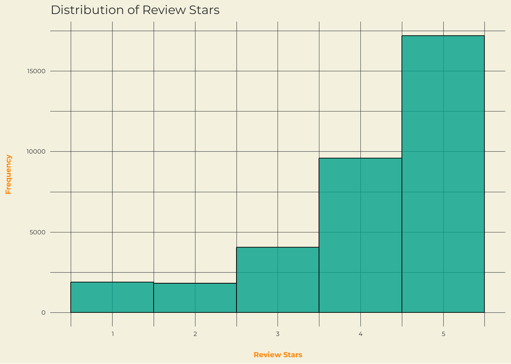

```r
ggplot(reviews, aes(x = Review.Stars)) +
  geom_histogram(binwidth = 1, fill = darjeeling1[2], color = "black", alpha = 0.8) +  # Set fill and outline colors
  scale_x_continuous(breaks = 1:5) +  # Set x-axis breaks to 1-5
  labs(title = "Distribution of Review Stars", x = "Review Stars", y = "Frequency")
```

We can see that the distribution of review stars is left skewed towards higher ratings, with a peak at 5 stars. This is a common pattern in review data, where people are more likely to leave reviews when they have strong positive or negative feelings about a product.

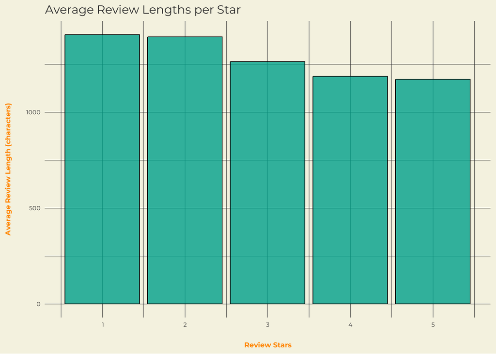

```r
reviews$Review.Length <- nchar(reviews$Review.Text)
avg_review_length <- reviews %>%
  group_by(Review.Stars) %>%
  summarise(Average.Length = mean(Review.Length))

# Plot the distribution of the average review length per star
ggplot(avg_review_length, aes(x = Review.Stars, y = Average.Length)) +
  geom_bar(stat = "identity", fill = darjeeling1[2], color="black", alpha=0.8) +
  labs(x = "Review Stars", y = "Average Review Length (characters)",
       title = "Average Review Lengths per Star")
```

We see that on average the reviews with lower ratings tend to be longer than those with higher ratings. This could be due to the fact that people are more likely to leave detailed reviews when they are dissatisfied with a book.

The most common words used in reviews, excluding the stop words and the words “book”, “books” and “read”.

```r
# Tokenize the review text into words
word_counts <- reviews %>%
  unnest_tokens(word, Review.Text) %>%  # Tokenize review text into words
  count(word, sort = TRUE) %>%          # Count occurrences of each word
  filter(!word %in% stop_words$word) %>%   # Remove stop words
  filter(!word %in% 'book', !word %in% 'books', !word %in% 'read')

# Create a word cloud using wordcloud2
wordcloud2(data = word_counts, size = 1, minSize = 1, shape = 'circle')
```

[interactive chart not shown]

Taking a look at the distribution of review stars for the top and worst rated books.

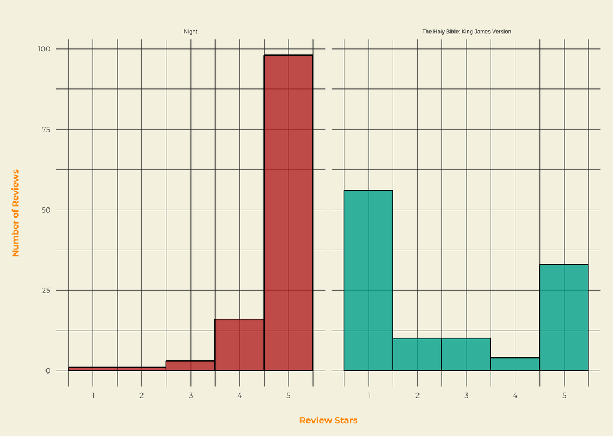

```r
# Calculate average ratings and get the top and worst book
top_and_worst_books <- reviews %>%
  group_by(Book.Title) %>%
  summarise(Average.Rating = mean(Review.Stars, na.rm = TRUE)) %>%
  arrange(Average.Rating) %>%
  slice(c(n(), 1))  # Select the top (last) and worst (first) book, reversing their order

# Filter reviews for the top and worst books
top_worst_reviews <- reviews %>%
  filter(Book.Title %in% top_and_worst_books$Book.Title)

# Create a separate distribution plot for each book
ggplot(top_worst_reviews, aes(x = Review.Stars, fill = Book.Title)) +
  geom_histogram(alpha = 0.8, color = "black", binwidth = 1) +  # Create bar plots for the distribution of stars
  facet_wrap(~ Book.Title, ncol = 2) +  # Create two separate plots side by side
  scale_fill_manual(values = darjeeling1[c(1, 2)]) +
  labs(
       x = "Review Stars",
       y = "Number of Reviews") +
  theme(legend.position = "none",   # Remove the legend
        plot.title = element_text(hjust = 0.5, size = 14),  # Center and adjust title size
        plot.margin = margin(t = 20, r = 10, b = 10, l = 10))  # Add margin space around the plot
```

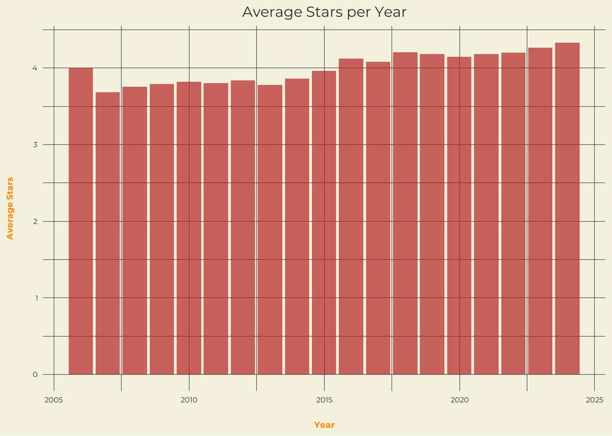

```r
# Calculate average stars per year
avg_stars_per_year <- reviews %>%
  mutate(year = year(Review.Date)) %>%         # Extract the year from Review.Date
  group_by(year) %>%                           # Group by year
  summarize(avg_stars = mean(Review.Stars, na.rm = TRUE))  # Calculate average stars per year

# Plot both bar plot and line plot for average stars per year
ggplot(avg_stars_per_year, aes(x = year, y = avg_stars)) +
  geom_col(fill = darjeeling1[1], alpha = 0.7) +  # Bar plot with fill color and some transparency
  labs(title = "Average Stars per Year",
       x = "Year",
       y = "Average Stars") +
  theme(plot.title = element_text(hjust = 0.5))
```

## Sentiment Analysis

We used the following 3 lexicons to calculate the sentiment score for each review: AFINN, Bing, and NRC.

```r
get_sentiments("afinn") %>% head(10)
```

```
## # A tibble: 10 × 2
##    word       value
##    <chr>      <dbl>
##  1 abandon       -2
##  2 abandoned     -2
##  3 abandons      -2
##  4 abducted      -2
##  5 abduction     -2
##  6 abductions    -2
##  7 abhor         -3
##  8 abhorred      -3
##  9 abhorrent     -3
## 10 abhors        -3
```

```r
get_sentiments("bing") %>% head(10)
```

```
## # A tibble: 10 × 2
##    word        sentiment
##    <chr>       <chr>
##  1 2-faces     negative
##  2 abnormal    negative
##  3 abolish     negative
##  4 abominable  negative
##  5 abominably  negative
##  6 abominate   negative
##  7 abomination negative
##  8 abort       negative
##  9 aborted     negative
## 10 aborts      negative
```

```r
get_sentiments("nrc") %>% head(10)
```

```
## # A tibble: 10 × 2
##    word        sentiment
##    <chr>       <chr>
##  1 abacus      trust
##  2 abandon     fear
##  3 abandon     negative
##  4 abandon     sadness
##  5 abandoned   anger
##  6 abandoned   fear
##  7 abandoned   negative
##  8 abandoned   sadness
##  9 abandonment anger
## 10 abandonment fear
```

The top ten books with the highest total sentiment score across all reviews, as well as the bottom ten books with the lowest total sentiment score across all reviews.

```r
reviews_sentiment <- reviews %>%
  unnest_tokens(word, Review.Text) %>%
  inner_join(get_sentiments("afinn")) %>%
  group_by(Book.Title) %>%
  summarize(sentiment = sum(value), avg_rating = mean(Review.Stars)) %>%
  arrange(desc(sentiment))
# View the top 10 books by sentiment score
head(reviews_sentiment, 10)
```

```
## # A tibble: 10 × 3
##    Book.Title                                sentiment avg_rating
##    <chr>                                         <dbl>      <dbl>
##  1 Harry Potter and the Sorcerer’s Stone          7776       3.87
##  2 The Lion, the Witch and the Wardrobe           7584       4.26
##  3 Leonardo da Vinci                              6840       4.11
##  4 Jane Eyre                                      6498       4.50
##  5 The Lightning Thief                            6270       4.13
##  6 Shoe Dog: A Memoir by the Creator of Nike      6256       4.24
##  7 Harry Potter and the Chamber of Secrets        6024       4.59
##  8 The Magician’s Nephew                          5328       4.27
##  9 Harry Potter and the Prisoner of Azkaban       5176       4.74
## 10 Anne of Green Gables                           5000       4.61
```

```r
reviews_sentiment %>% arrange(sentiment) %>% head(10)
```

```
## # A tibble: 10 × 3
##    Book.Title                                               sentiment avg_rating
##    <chr>                                                        <dbl>      <dbl>
##  1 Night                                                         -367       4.77
##  2 Spare                                                         -197       3.40
##  3 Bad Blood: Secrets and Lies in a Silicon Valley Startup       -124       4.38
##  4 A Grief Observed                                              -114       4.44
##  5 Angela’s Ashes                                                   0       4.02
##  6 The Lonely City: Adventures in the Art of Being Alone           20       4.02
##  7 Unbroken: A World War II Story of Survival, Resilience …        86       4.44
##  8 The Autobiography of Malcolm X                                 123       4.58
##  9 Narrative of the Life of Frederick Douglass                    130       4.68
## 10 Camera Lucida: Reflections on Photography                      222       3.90
```

The book Night has the lowest total sentiment score across all reviews yet it also has the highest average rating across all reviews.

#### Genres for top and worst rated books

```r
# Join the reviews_sentiment dataset with the books_genres dataset
sentiment_with_genres <- reviews_sentiment %>%
  left_join(book_genres, by = "Book.Title")

# Get the top 10 highest sentiment books
top_highest_sentiment <- sentiment_with_genres %>%
  arrange(desc(sentiment)) %>%
  head(10)

# Get the top 10 lowest sentiment books
top_lowest_sentiment <- sentiment_with_genres %>%
  arrange(sentiment) %>%
  head(10)

# Print the results
print("Top 10 Highest Sentiment Books with Genres:")
```

```
## [1] "Top 10 Highest Sentiment Books with Genres:"
```

```r
print(top_highest_sentiment %>%
  select(Book.Title, Genres))
```

```
## # A tibble: 10 × 2
##    Book.Title                            Genres
##    <chr>                                 <chr>
##  1 Harry Potter and the Sorcerer’s Stone Fantasy, Fiction, Young Adult, Magic, …
##  2 Harry Potter and the Sorcerer’s Stone Fantasy, Fiction, Young Adult, Magic, …
##  3 Harry Potter and the Sorcerer’s Stone Fantasy, Fiction, Young Adult, Magic, …
##  4 Harry Potter and the Sorcerer’s Stone Fantasy, Fiction, Young Adult, Magic, …
##  5 The Lion, the Witch and the Wardrobe  Fantasy, Fiction, Young Adult, Childre…
##  6 The Lion, the Witch and the Wardrobe  Fantasy, Fiction, Young Adult, Childre…
##  7 The Lion, the Witch and the Wardrobe  Fantasy, Fiction, Young Adult, Childre…
##  8 Leonardo da Vinci                     Biography, Nonfiction, History, Art, S…
##  9 Leonardo da Vinci                     Biography, Nonfiction, History, Art, S…
## 10 Jane Eyre                             Classics, Fiction, Historical Fiction,…
```

```r
print("Top 10 Lowest Sentiment Books with Genres:")
```

```
## [1] "Top 10 Lowest Sentiment Books with Genres:"
```

```r
print(top_lowest_sentiment %>%
  select(Book.Title, Genres))
```

```
## # A tibble: 10 × 2
##    Book.Title                                                            Genres
##    <chr>                                                                 <chr>
##  1 Night                                                                 Nonfic…
##  2 Spare                                                                 Nonfic…
##  3 Bad Blood: Secrets and Lies in a Silicon Valley Startup               Nonfic…
##  4 A Grief Observed                                                      Nonfic…
##  5 Angela’s Ashes                                                        Nonfic…
##  6 The Lonely City: Adventures in the Art of Being Alone                 Nonfic…
##  7 Unbroken: A World War II Story of Survival, Resilience and Redemption Nonfic…
##  8 The Autobiography of Malcolm X                                        Nonfic…
##  9 Narrative of the Life of Frederick Douglass                           Nonfic…
## 10 Camera Lucida: Reflections on Photography                             Photog…
```

Upon investigating the genres for the book Night, we see that the book is a historical biography about the holocaust which explains the low sentiment score for all the reviews. It is evident that the sentiment score is not a good indicator of the overall rating of a book. This is because the sentiment score is based on the sentiment of the words used in the reviews, which may not always reflect the overall sentiment of the review. For example, a review may contain positive sentiment words but still give a low rating to the book, or vice versa.

### Sentiment Analysis using NRC Lexicon

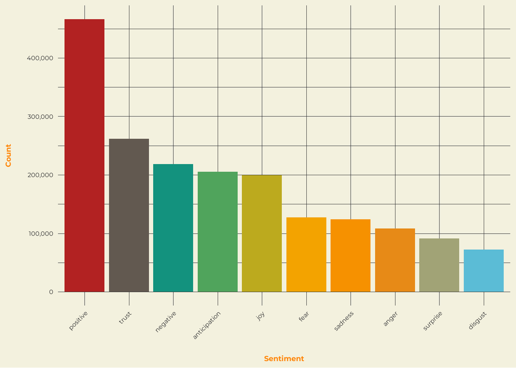

```r
extended_palette <- colorRampPalette(darjeeling1)

# Tokenize the review text into words and calculate sentiment counts
sentiment_counts <- reviews %>%
  unnest_tokens(word, Review.Text) %>%          # Tokenize review text into words
  inner_join(get_sentiments("nrc"), by = "word", relationship = "many-to-many") %>% # Join with NRC lexicon
  count(sentiment) %>%                          # Count occurrences of each sentiment
  arrange(desc(n))

# Reorder sentiment factor levels by count
sentiment_counts$sentiment <- factor(sentiment_counts$sentiment, levels = sentiment_counts$sentiment)

# Get the number of unique sentiments
num_sentiments <- length(unique(sentiment_counts$sentiment))

ggplot(sentiment_counts, aes(x = sentiment, y = n, fill = sentiment)) +
  geom_bar(stat = "identity", width = 0.9) +
  labs( x = "Sentiment", y = "Count") +
  scale_fill_manual(values = extended_palette(num_sentiments)) +  # Extend the palette to match sentiments
  theme(legend.position = "none",
        axis.text.x = element_text(angle = 45, hjust = 1)) + # Customize axis titles
  scale_y_continuous(labels = scales::comma)
```

### Sentiment Analysis using Bing Lexicon

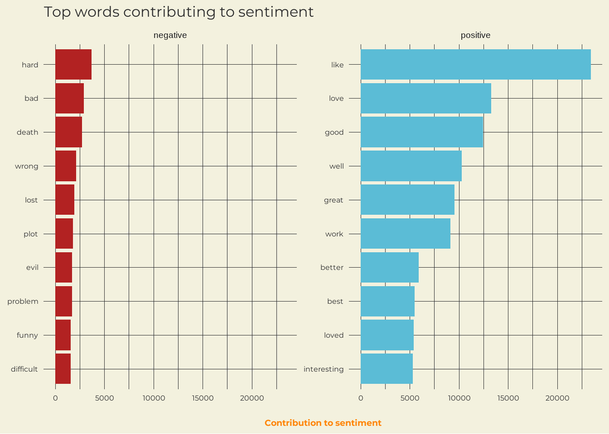

```r
bing_word_counts <- reviews %>%
  unnest_tokens(word, Review.Text) %>%
  inner_join(get_sentiments("bing"), by = join_by(word),relationship = "many-to-many") %>%
  count(word, sentiment, sort = TRUE) %>%
  ungroup()

bing_word_counts %>%
  group_by(sentiment) %>%
  slice_max(n, n = 10) %>%
  ungroup() %>%
  ggplot(aes(n, reorder(word, n), fill = sentiment)) +
  geom_col(show.legend = FALSE) +
  facet_wrap(~sentiment, scales = "free_y") +
  labs(x = "Contribution to sentiment", y = NULL,title = "Top words contributing to sentiment") +
  scale_fill_manual(values = c("positive" = darjeeling1[5],   # Set a color for positive sentiment
                               "negative" = darjeeling1[1])) +  # Set a color for negative sentiment
  theme(strip.text = element_text(size = 14))
```

### Question: How does the sentiment of reviews correlate with the star rating given?

```r
# Calculate sentiment score for each review
sentiment_scores <- reviews %>%
  unnest_tokens(word, Review.Text) %>%
  inner_join(get_sentiments("afinn"), by = join_by(word)) %>%
  group_by(Book.Title, Link, Review.Date, Review.Stars, Review.Likes, Genres) %>%
  summarize(sentiment_score = sum(value), .groups = 'drop')

# Calculate correlation
correlation <- cor(sentiment_scores$Review.Stars, sentiment_scores$sentiment_score)
print(paste("Correlation between sentiment score and review stars:", correlation))
```

```
## [1] "Correlation between sentiment score and review stars: 0.103139280361126"
```

The correlation between sentiment score and review stars is 0.103, indicating a weak positive correlation between the two variables. This suggests that reviews with higher sentiment scores tend to have higher star ratings, but the relationship is not very strong.

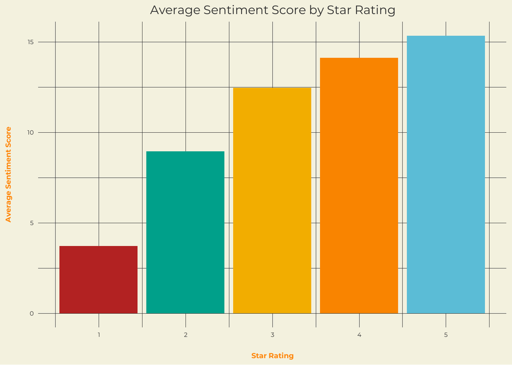

```r
# Average sentiment score by star rating
avg_sentiment_by_stars <- sentiment_scores %>%
  group_by(Review.Stars) %>%
  summarize(avg_sentiment = mean(sentiment_score))

ggplot(avg_sentiment_by_stars, aes(x = Review.Stars, y = avg_sentiment)) +
  geom_col(fill = darjeeling1) +
  labs(title = "Average Sentiment Score by Star Rating",
       x = "Star Rating",
       y = "Average Sentiment Score") +
  theme(plot.title = element_text(hjust = 0.5))
```

The plot above shows the average sentiment score for each star rating. We can see that reviews with higher star ratings tend to have higher average sentiment scores, which is consistent with the weak positive correlation between sentiment score and review stars.

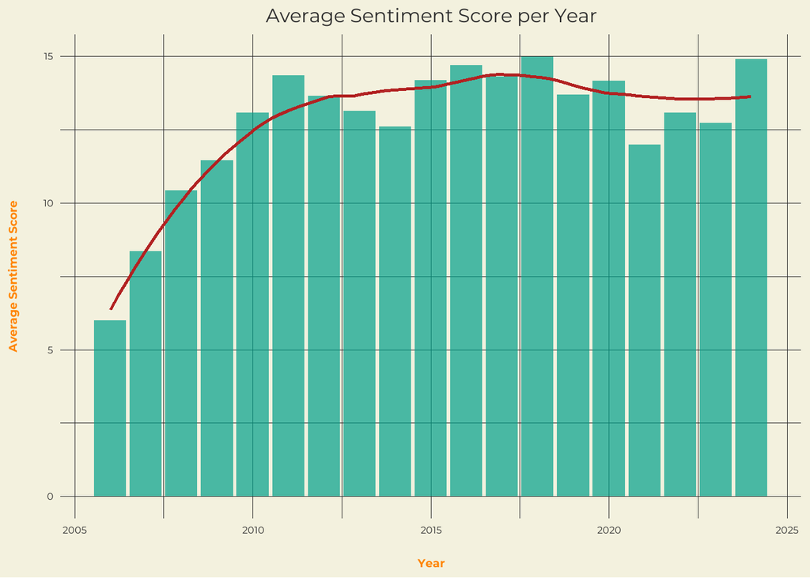

```r
avg_sentiment_per_year <- sentiment_scores %>%
  mutate(year = year(Review.Date)) %>%         # Extract the year from Review.Date
  group_by(year) %>%                           # Group by year
  summarize(avg_sentiment_score = mean(sentiment_score, na.rm = TRUE))  # Calculate average sentiment score

# Plot the average sentiment score per year as a histogram
ggplot(avg_sentiment_per_year, aes(x = year, y = avg_sentiment_score)) +
  geom_col(fill = darjeeling1[2], alpha = 0.7) +  # Use geom_col to create a histogram
  geom_smooth(method = "loess", se = FALSE, color = darjeeling1[1]) +
  labs(title = "Average Sentiment Score per Year",
       x = "Year",
       y = "Average Sentiment Score") +
  theme(plot.title = element_text(hjust = 0.5))
```

## NLP Question: Which review words resulted in highest rating?

First let’s clean the dataset for our specific purpose. The words should also be tokenized and stopwords removed.

```r
replace_reg <- "(https?:.*?([\\s]|[a-zA-Z0-9]$))|(www:.*?([\\s]|[a-zA-Z0-9]$))"
unnest_reg <- "[^A-Za-z_\\d#@']"
# Select the relevant columns
words_rating_reviews <- reviews %>%
  select(Review.Text, Review.Stars)

# Tokenize the review text
words_ratings <- words_rating_reviews %>%
  unnest_tokens(word, Review.Text, token = "regex", pattern = unnest_reg, drop = FALSE) %>%
  anti_join(stop_words, by = join_by(word)) # Remove stop words
```

```r
# Calculate average ratings for each word
word_avg_ratings <- words_ratings %>%
  group_by(word) %>%
  summarise(
    avg_rating = mean(Review.Stars),
    count = n()
  ) %>%
  filter(count >= 10)  # Filter words that appear at least 10 times
```

```r
# Find the words with the highest ratings
top_words <- word_avg_ratings %>%
  arrange(desc(avg_rating)) %>%
  head(20)

# Display the results
print(top_words)
```

```
## # A tibble: 20 × 3
##    word        avg_rating count
##    <chr>            <dbl> <int>
##  1 2728                 5    17
##  2 7200                 5    20
##  3 abby                 5    10
##  4 aberforth            5    12
##  5 andromeda            5    12
##  6 anythings            5    12
##  7 ariana               5    12
##  8 auror                5    32
##  9 avengers             5    15
## 10 bagman               5    20
## 11 barty                5    32
## 12 beauxbatons          5    20
## 13 bellowed             5    11
## 14 berthas              5    12
## 15 betsies              5    10
## 16 binns                5    12
## 17 blastended           5    12
## 18 boenhoeffer          5    15
## 19 boggart              5    36
## 20 bonnhoeffer          5    11
```

```r
# Find the words with the lowest ratings
bottom_words <- word_avg_ratings %>%
  arrange(avg_rating) %>%
  head(20)

# Display the results
print(bottom_words)
```

```
## # A tibble: 20 × 3
##    word                 avg_rating count
##    <chr>                     <dbl> <int>
##  1 causationcorrelation       1       25
##  2 sueness                    1       16
##  3 causation                  1.07   498
##  4 horoscope                  1.2     10
##  5 correlation                1.24   544
##  6 imply                      1.25   566
##  7 turbanwearing              1.5     16
##  8 eph                        1.52    21
##  9 goblin                     1.57    35
## 10 unoriginal                 1.6     20
## 11 calor                      1.62    13
## 12 eldredges                  1.62    63
## 13 parasite                   1.62    16
## 14 jn                         1.68    19
## 15 barf                       1.69    13
## 16 mindnumbingly              1.7     10
## 17 hottie                     1.77    13
## 18 drivel                     1.79    39
## 19 eldredge                   1.81   154
## 20 specialness                1.82    11
```

Apart from the irrelevant words such as author names etc., the positive words that stand out are: “bellowed”, “anythings”, “avengers”, “blastended”. The negative words that stand out are: “causation”, “correlation”, “unoriginal”, “imply”, “mindnumbingly”. As somewhat is to be expected, the common words that result in high reviews don’t generalize well across books. No trend can easily be identified from this top average rating list.

## Topic Analysis Question: What are the most common topics or themes discussed in positive vs. negative reviews?

```r
unordered_books_sentiment <- sentiment_scores %>%
  group_by(Book.Title) %>%
  summarize(avg_sentiment = mean(sentiment_score),
            avg_stars = mean(Review.Stars),
            review_count = n())
head(unordered_books_sentiment)
```

```
## # A tibble: 6 × 4
##   Book.Title                                avg_sentiment avg_stars review_count
##   <chr>                                             <dbl>     <dbl>        <int>
## 1 "\"Surely You're Joking, Mr. Feynman!\":…        14.8        4.09          119
## 2 "A Grief Observed"                               -0.991      4.47          115
## 3 "A Light in the Attic"                            7.02       4.32          111
## 4 "A Little Princess"                              28.8        4.41          116
## 5 "A Promised Land"                                13.8        4.48          111
## 6 "A Voice in the Wind"                            12.1        4.17          108
```

```r
# Join the sentiment scores with the reviews
top_book_reviews <- unordered_books_sentiment %>%
  inner_join(reviews, by = "Book.Title") %>%
  select(Book.Title, Review.Text, Review.Stars, avg_sentiment)

top_book_reviews <- top_book_reviews %>%
  mutate(review_type = case_when(
    Review.Stars >= 4 ~ "Positive",
    Review.Stars <= 2 ~ "Negative",
    TRUE ~ "Neutral"
  ))

# Tokenize the review text
tokenized_reviews <- top_book_reviews %>%
  unnest_tokens(word, Review.Text)

# Remove stop words
data("stop_words")
tokenized_reviews <- tokenized_reviews %>%
  anti_join(stop_words, by = "word")

# Count the most frequent words in positive and negative reviews
word_count <- tokenized_reviews %>%
  filter(review_type != "Neutral") %>%
  group_by(review_type, word) %>%
  summarize(count = n()) %>%
  arrange(desc(count))
# Top words in positive reviews
top_positive_words <- word_count %>%
  filter(review_type == "Positive") %>%
  arrange(desc(count)) %>%
  head(10)

# Top words in negative reviews
top_negative_words <- word_count %>%
  filter(review_type == "Negative") %>%
  arrange(desc(count)) %>%
  head(10)

# View results
top_positive_words
```

```
## # A tibble: 10 × 3
## # Groups:   review_type [1]
##    review_type word    count
##    <chr>       <chr>   <int>
##  1 Positive    book    50394
##  2 Positive    read    24810
##  3 Positive    time    14906
##  4 Positive    life    13754
##  5 Positive    story   11849
##  6 Positive    love    11059
##  7 Positive    reading 10777
##  8 Positive    people  10659
##  9 Positive    books   10024
## 10 Positive    harry    9265
```

```r
top_negative_words
```

```
## # A tibble: 10 × 3
## # Groups:   review_type [1]
##    review_type word    count
##    <chr>       <chr>   <int>
##  1 Negative    book     9926
##  2 Negative    read     3284
##  3 Negative    people   2573
##  4 Negative    dont     2154
##  5 Negative    time     1920
##  6 Negative    im       1773
##  7 Negative    god      1603
##  8 Negative    story    1470
##  9 Negative    life     1437
## 10 Negative    reading  1405
```

From this, we can see a lot of overlap (which makes sense in most cases since certain words are very likely to be used in book reviews in general - i.e. book, read, people, time). It would seem helpful to exclude these overlapping words when trying to distinguish unique themes or topics, but this would shrink the word counts (particularly for negative reviews) as shown below.

```r
# Step 1: Identify overlapping words
cleaned_word_count <- word_count %>%
  filter(str_detect(word, "^[a-zA-Z]+$"))  %>%   # Keep only English alphabetic words
  filter(!str_detect(word, "\\d"))


overlap_words <- intersect(
  cleaned_word_count %>% filter(review_type == "Positive") %>% pull(word),
  cleaned_word_count %>% filter(review_type == "Negative") %>% pull(word)
)

# Step 2: Exclude overlapping words
filtered_word_count <- cleaned_word_count %>%
  filter(!word %in% overlap_words)

# Step 3: Get the top unique words for positive reviews
top_positive_unique_words <- filtered_word_count %>%
  filter(review_type == "Positive") %>%
  arrange(desc(count)) %>%
  head(10)
# Step 4: Get the top unique words for negative reviews
top_negative_unique_words <- filtered_word_count %>%
  filter(review_type == "Negative") %>%
  arrange(desc(count)) %>%
  head(10)

# View the results
top_positive_unique_words
```

```
## # A tibble: 10 × 3
## # Groups:   review_type [1]
##    review_type word       count
##    <chr>       <chr>      <int>
##  1 Positive    azkaban      404
##  2 Positive    douglass     253
##  3 Positive    lockhart     224
##  4 Positive    marilla      218
##  5 Positive    dementors    180
##  6 Positive    grinch       148
##  7 Positive    hermoine     144
##  8 Positive    enchanting   142
##  9 Positive    grover       140
## 10 Positive    triwizard    132
```

```r
top_negative_unique_words
```

```
## # A tibble: 10 × 3
## # Groups:   review_type [1]
##    review_type word                 count
##    <chr>       <chr>                <int>
##  1 Negative    causationcorrelation    25
##  2 Negative    sueness                 16
##  3 Negative    tempera                 16
##  4 Negative    turbanwearing           16
##  5 Negative    zimatar                 16
##  6 Negative    unoriginal              15
##  7 Negative    calor                   13
##  8 Negative    horoscope                9
##  9 Negative    percyharry               9
## 10 Negative    reintroduces             9
```

It is important to note that our corpus of reviews consists of multiple harry potter books and thus removing the overlapping words will result in a significant reduction in the number of common words used in reviews adn the next most common words will become the words in the reviews that we have the most of - which are the Harry Potter books.

On the other hand, negative reviews introduce terms that criticize certain aspects of the books or other elements. Words like “Causation and Correlation” (25 mentions) could suggest critiques of plot logic, while “Unoriginal” (15 mentions) points to a common reader complaint about repetitive or derivative elements. Terms like “Sueness” (16 mentions) and “Zimatar” (16 mentions) also highlight frustration with specific character traits or plot points.

## Question: Can we detect sarcasm or irony in reviews, and how does it relate to the overall rating?

Sarcasm and irony are very challenging concepts to detect. A rudimentary way of tackling such an issue like this could be further sentiment analysis. This would entail analyzing negative reviews that contain positive sentiment.

```r
sentiment_scores <- top_book_reviews %>%
  unnest_tokens(word, Review.Text) %>%            # Tokenize the review text
  inner_join(get_sentiments("bing"), by = "word", relationship = "many-to-many") %>%  # Join with sentiment lexicon
  count(Book.Title, Review.Stars, sentiment) %>%  # Count occurrences of positive/negative words
  spread(sentiment, n, fill = 0) %>%               # Spread sentiment into separate columns
  mutate(sentiment_score = positive - negative)     # Calculate sentiment score
# View sentiment scores
head(sentiment_scores)
```

```
## # A tibble: 6 × 5
##   Book.Title                      Review.Stars negative positive sentiment_score
##   <chr>                                  <int>    <dbl>    <dbl>           <dbl>
## 1 "\"Surely You're Joking, Mr. F…            1      103      124              21
## 2 "\"Surely You're Joking, Mr. F…            2       81      121              40
## 3 "\"Surely You're Joking, Mr. F…            3      103      124              21
## 4 "\"Surely You're Joking, Mr. F…            4      136      293             157
## 5 "\"Surely You're Joking, Mr. F…            5      454      888             434
## 6 "A Grief Observed"                         1        5        1              -4
```

From here, we can plot which books have the greatest sentiment score for reviews with less than 3 stars - which could direct us to reviews that have sarcasm/irony.

```r
sarcastic_books <- sentiment_scores %>%
  filter(Review.Stars < 3, sentiment_score > 0)

# Print the resulting books
print(sarcastic_books)
```

```
## # A tibble: 261 × 5
##    Book.Title                     Review.Stars negative positive sentiment_score
##    <chr>                                 <int>    <dbl>    <dbl>           <dbl>
##  1 "\"Surely You're Joking, Mr. …            1      103      124              21
##  2 "\"Surely You're Joking, Mr. …            2       81      121              40
##  3 "A Little Princess"                       2      132      220              88
##  4 "A Voice in the Wind"                     1       36       44               8
##  5 "A Voice in the Wind"                     2      227      250              23
##  6 "A Wrinkle in Time"                       2      172      215              43
##  7 "Alice’s Adventures in Wonder…            2       67       73               6
##  8 "An Illustrated Life: Drawing…            2       17       25               8
##  9 "Anne of Green Gables"                    2       10       16               6
## 10 "Art and Fear"                            2       75       92              17
## # ℹ 251 more rows
```

```r
top_n_books <- sarcastic_books %>%
  arrange(desc(sentiment_score)) %>%
  filter(!Book.Title %in% "Shoe Dog: A Memoir by the Creator of Nike") %>% # causes unknow issue with the plot
  head(10)

# Print the resulting top books
head(top_n_books)
```

```
## # A tibble: 6 × 5
##   Book.Title                      Review.Stars negative positive sentiment_score
##   <chr>                                  <int>    <dbl>    <dbl>           <dbl>
## 1 Harry Potter and the Sorcerer’…            1      916     1108             192
## 2 Lean In: Women, Work, and the …            2      141      328             187
## 3 The 4-Hour Workweek                        2      202      382             180
## 4 Redeeming Love                             1      458      617             159
## 5 Love Does: Discover a Secretly…            2      132      283             151
## 6 Leonardo da Vinci                          2      252      396             144
```

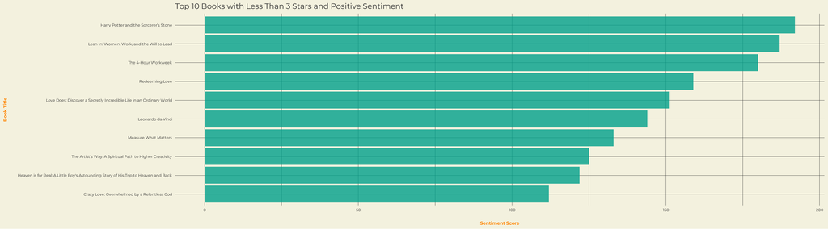

```r
ggplot(top_n_books, aes(x = reorder(Book.Title, sentiment_score), y = sentiment_score)) +
  geom_col(fill = darjeeling1[2], alpha=0.8) +
  labs(title = "Top 10 Books with Less Than 3 Stars and Positive Sentiment",
       x = "Book Title",
       y = "Sentiment Score") +
  coord_flip()
```

For these books to have 1 or 2 star reviews with such high sentiment scores definitely indicate that there is probably some form of expression where the intended meaning differs from the literal meaning of the words used. After seeing these results, all that is left is to read the reviews ourselves to gauge whether or not these reviews contain verbal irony.

```r
average_ratings <- reviews %>%
  group_by(Book.Title) %>%
  summarize(avg_rating = mean(Review.Stars))

head(average_ratings)
```

```
## # A tibble: 6 × 2
##   Book.Title                                                          avg_rating
##   <chr>                                                                    <dbl>
## 1 "\"Surely You're Joking, Mr. Feynman!\": Adventures of a Curious C…       4.09
## 2 "A Grief Observed"                                                        4.47
## 3 "A Light in the Attic"                                                    4.35
## 4 "A Little Princess"                                                       4.41
## 5 "A Promised Land"                                                         4.48
## 6 "A Voice in the Wind"                                                     4.18
```

```r
# Filter for sarcastic reviews
sarcastic_reviews <- sentiment_scores %>%
  filter(sentiment_score > 0, Review.Stars <= 2)

# Create a sarcasm indicator in the sarcastic_reviews dataframe
sarcastic_reviews <- sarcastic_reviews %>%
  mutate(sarcasm = 1)

# Create a non-sarcastic data frame for comparison
non_sarcastic_reviews <- sentiment_scores %>%
  filter(!(sentiment_score > 0 & Review.Stars <= 2)) %>%
  mutate(sarcasm = 0)

# Combine both data frames
combined_reviews <- bind_rows(sarcastic_reviews, non_sarcastic_reviews)

# Merge with average ratings to include average book rating
final_analysis <- combined_reviews %>%
  group_by(Book.Title) %>%
  summarize(sentiment_score = mean(sentiment_score, na.rm = TRUE),
            sarcasm = first(sarcasm)) %>%
  mutate(avg_rating = average_ratings$avg_rating)

# Calculate correlation between sentiment score and average rating
head(final_analysis)
```

```
## # A tibble: 6 × 4
##   Book.Title                                  sentiment_score sarcasm avg_rating
##   <chr>                                                 <dbl>   <dbl>      <dbl>
## 1 "\"Surely You're Joking, Mr. Feynman!\": A…           135.        1       4.09
## 2 "A Grief Observed"                                    -53.6       0       4.47
## 3 "A Light in the Attic"                                 35.8       0       4.35
## 4 "A Little Princess"                                   236         1       4.41
## 5 "A Promised Land"                                     138.        0       4.48
## 6 "A Voice in the Wind"                                  64.2       1       4.18
```

```r
correlation_result <- cor(final_analysis$sentiment_score, final_analysis$avg_rating)
print(paste("Correlation between sentiment score and average book rating:", correlation_result))
```

```
## [1] "Correlation between sentiment score and average book rating: 0.162625105218989"
```

```r
# Run a linear regression analysis
model <- lm(avg_rating ~ sentiment_score + sarcasm, data = final_analysis)
summary(model)
```

```
##
## Call:
## lm(formula = avg_rating ~ sentiment_score + sarcasm, data = final_analysis)
##
## Residuals:
##      Min       1Q   Median       3Q      Max
## -1.57352 -0.25039  0.06152  0.27290  0.89624
##
## Coefficients:
##                   Estimate Std. Error t value Pr(>|t|)
## (Intercept)      4.1159548  0.0550787  74.729  < 2e-16 ***
## sentiment_score  0.0008156  0.0002463   3.312 0.001073 **
## sarcasm         -0.2147899  0.0617132  -3.480 0.000597 ***
## ---
## Signif. codes:  0 '***' 0.001 '**' 0.01 '*' 0.05 '.' 0.1 ' ' 1
##
## Residual standard error: 0.4112 on 235 degrees of freedom
## Multiple R-squared:  0.07417,    Adjusted R-squared:  0.06629
## F-statistic: 9.413 on 2 and 235 DF,  p-value: 0.0001168
```

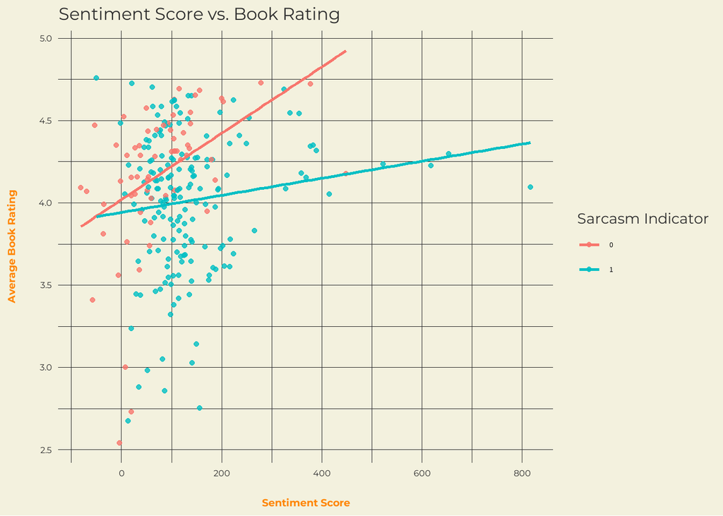

```r
ggplot(final_analysis, aes(x = sentiment_score, y = avg_rating, color = factor(sarcasm))) +
  geom_point(alpha = 0.8) +
  geom_smooth(method = "lm", se = FALSE) +
  labs(title = "Sentiment Score vs. Book Rating",
       x = "Sentiment Score",
       y = "Average Book Rating",
       color = "Sarcasm Indicator")
```

In conclusion, it is fair to say that there MIGHT be some evidence of sarcastic reviews having an impact on the overall rating, but it is more likely that other variables are more important in predicting overall review scores.